# INN Hotels Project

## Context

A significant number of hotel bookings are called-off due to cancellations or no-shows. The typical reasons for cancellations include change of plans, scheduling conflicts, etc. This is often made easier by the option to do so free of charge or preferably at a low cost which is beneficial to hotel guests but it is a less desirable and possibly revenue-diminishing factor for hotels to deal with. Such losses are particularly high on last-minute cancellations.

The new technologies involving online booking channels have dramatically changed customers’ booking possibilities and behavior. This adds a further dimension to the challenge of how hotels handle cancellations, which are no longer limited to traditional booking and guest characteristics.

The cancellation of bookings impact a hotel on various fronts:

- Loss of resources (revenue) when the hotel cannot resell the room.
- Additional costs of distribution channels by increasing commissions or paying for publicity to help sell these rooms.
- Lowering prices last minute, so the hotel can resell a room, resulting in reducing the profit margin.
- Human resources to make arrangements for the guests.

## Objective

The increasing number of cancellations calls for a Machine Learning based solution that can help in predicting which booking is likely to be canceled. INN Hotels Group has a chain of hotels in Portugal, they are facing problems with the high number of booking cancellations and have reached out to your firm for data-driven solutions. You as a data scientist have to analyze the data provided to find which factors have a high influence on booking cancellations, build a predictive model that can predict which booking is going to be canceled in advance, and help in formulating profitable policies for cancellations and refunds.

## Data Description

The data contains the different attributes of customers' booking details. The detailed data dictionary is given below.

**Data Dictionary**

- Booking_ID: unique identifier of each booking
- no_of_adults: Number of adults
- no_of_children: Number of Children
- no_of_weekend_nights: Number of weekend nights (Saturday or Sunday) the guest stayed or booked to stay at the hotel
- no_of_week_nights: Number of week nights (Monday to Friday) the guest stayed or booked to stay at the hotel
- type_of_meal_plan: Type of meal plan booked by the customer:
  - Not Selected – No meal plan selected
  - Meal Plan 1 – Breakfast
  - Meal Plan 2 – Half board (breakfast and one other meal)
  - Meal Plan 3 – Full board (breakfast, lunch, and dinner)
- required_car_parking_space: Does the customer require a car parking space? (0 - No, 1- Yes)
- room_type_reserved: Type of room reserved by the customer. The values are ciphered (encoded) by INN Hotels.
- lead_time: Number of days between the date of booking and the arrival date
- arrival_year: Year of arrival date
- arrival_month: Month of arrival date
- arrival_date: Date of the month
- market_segment_type: Market segment designation.
- repeated_guest: Is the customer a repeated guest? (0 - No, 1- Yes)
- no_of_previous_cancellations: Number of previous bookings that were canceled by the customer prior to the current booking
- no_of_previous_bookings_not_canceled: Number of previous bookings not canceled by the customer prior to the current booking
- avg_price_per_room: Average price per day of the reservation; prices of the rooms are dynamic. (in euros)
- no_of_special_requests: Total number of special requests made by the customer (e.g. high floor, view from the room, etc)
- booking_status: Flag indicating if the booking was canceled or not.

## Importing necessary libraries and data

```python
# this will help in making the Python code more structured automatically (help adhere to good coding practices)
#%load_ext nb_black

import warnings

warnings.filterwarnings("ignore")
from statsmodels.tools.sm_exceptions import ConvergenceWarning

warnings.simplefilter("ignore", ConvergenceWarning)

# Libraries to help with reading and manipulating data
import pandas as pd
import numpy as np

# libaries to help with data visualization
import matplotlib.pyplot as plt
import seaborn as sns

# Removes the limit for the number of displayed columns
pd.set_option("display.max_columns", None)
# Sets the limit for the number of displayed rows
pd.set_option("display.max_rows", 200)
# setting the precision of floating numbers to 5 decimal points
pd.set_option("display.float_format", lambda x: "%.5f" % x)

# Library to split data
from sklearn.model_selection import train_test_split

# To build model for prediction
import statsmodels.stats.api as sms
from statsmodels.stats.outliers_influence import variance_inflation_factor
import statsmodels.api as sm
from statsmodels.tools.tools import add_constant
from sklearn.tree import DecisionTreeClassifier
from sklearn import tree

# To tune different models
from sklearn.model_selection import GridSearchCV


# To get diferent metric scores
from sklearn.metrics import (
    f1_score,
    accuracy_score,
    recall_score,
    precision_score,
    confusion_matrix,
    roc_auc_score,
    ConfusionMatrixDisplay,
    precision_recall_curve,
    roc_curve,
    make_scorer,
)
```

### Loading the Dataset

```python
from google.colab import drive
drive.mount("/content/drive")
```

```python
george = pd.read_csv('/content/drive/My Drive/Colab Notebooks/INNHotelsGroup.csv')
```

```python
data = george.copy()
```

## Data Overview

```python
# First five rows of the dataset
data.head()
```

|  | Booking_ID | no_of_adults | no_of_children | no_of_weekend_nights | no_of_week_nights | type_of_meal_plan | required_car_parking_space | room_type_reserved | lead_time | arrival_year | arrival_month | arrival_date | market_segment_type | repeated_guest | no_of_previous_cancellations | no_of_previous_bookings_not_canceled | avg_price_per_room | no_of_special_requests | booking_status |
| --- | --- | --- | --- | --- | --- | --- | --- | --- | --- | --- | --- | --- | --- | --- | --- | --- | --- | --- | --- |
| 0 | INN00001 | 2 | 0 | 1 | 2 | Meal Plan 1 | 0 | Room_Type 1 | 224 | 2017 | 10 | 2 | Offline | 0 | 0 | 0 | 65.00000 | 0 | Not_Canceled |
| 1 | INN00002 | 2 | 0 | 2 | 3 | Not Selected | 0 | Room_Type 1 | 5 | 2018 | 11 | 6 | Online | 0 | 0 | 0 | 106.68000 | 1 | Not_Canceled |
| 2 | INN00003 | 1 | 0 | 2 | 1 | Meal Plan 1 | 0 | Room_Type 1 | 1 | 2018 | 2 | 28 | Online | 0 | 0 | 0 | 60.00000 | 0 | Canceled |
| 3 | INN00004 | 2 | 0 | 0 | 2 | Meal Plan 1 | 0 | Room_Type 1 | 211 | 2018 | 5 | 20 | Online | 0 | 0 | 0 | 100.00000 | 0 | Canceled |
| 4 | INN00005 | 2 | 0 | 1 | 1 | Not Selected | 0 | Room_Type 1 | 48 | 2018 | 4 | 11 | Online | 0 | 0 | 0 | 94.50000 | 0 | Canceled |

```python
# Last five rows of the dataset
data.tail()
```

|  | Booking_ID | no_of_adults | no_of_children | no_of_weekend_nights | no_of_week_nights | type_of_meal_plan | required_car_parking_space | room_type_reserved | lead_time | arrival_year | arrival_month | arrival_date | market_segment_type | repeated_guest | no_of_previous_cancellations | no_of_previous_bookings_not_canceled | avg_price_per_room | no_of_special_requests | booking_status |
| --- | --- | --- | --- | --- | --- | --- | --- | --- | --- | --- | --- | --- | --- | --- | --- | --- | --- | --- | --- |
| 36270 | INN36271 | 3 | 0 | 2 | 6 | Meal Plan 1 | 0 | Room_Type 4 | 85 | 2018 | 8 | 3 | Online | 0 | 0 | 0 | 167.80000 | 1 | Not_Canceled |
| 36271 | INN36272 | 2 | 0 | 1 | 3 | Meal Plan 1 | 0 | Room_Type 1 | 228 | 2018 | 10 | 17 | Online | 0 | 0 | 0 | 90.95000 | 2 | Canceled |
| 36272 | INN36273 | 2 | 0 | 2 | 6 | Meal Plan 1 | 0 | Room_Type 1 | 148 | 2018 | 7 | 1 | Online | 0 | 0 | 0 | 98.39000 | 2 | Not_Canceled |
| 36273 | INN36274 | 2 | 0 | 0 | 3 | Not Selected | 0 | Room_Type 1 | 63 | 2018 | 4 | 21 | Online | 0 | 0 | 0 | 94.50000 | 0 | Canceled |
| 36274 | INN36275 | 2 | 0 | 1 | 2 | Meal Plan 1 | 0 | Room_Type 1 | 207 | 2018 | 12 | 30 | Offline | 0 | 0 | 0 | 161.67000 | 0 | Not_Canceled |

```python
# Shape of the dataset
data.shape
```

```
(36275, 19)
```

- There are 36275 rows and 19 columns in the dataset.

```python
# Checking the datatypes of the columns in the dataset
data.info()
```

```
<class 'pandas.core.frame.DataFrame'>
RangeIndex: 36275 entries, 0 to 36274
Data columns (total 19 columns):
 #   Column                                Non-Null Count  Dtype
---  ------                                --------------  -----
 0   Booking_ID                            36275 non-null  object
 1   no_of_adults                          36275 non-null  int64
 2   no_of_children                        36275 non-null  int64
 3   no_of_weekend_nights                  36275 non-null  int64
 4   no_of_week_nights                     36275 non-null  int64
 5   type_of_meal_plan                     36275 non-null  object
 6   required_car_parking_space            36275 non-null  int64
 7   room_type_reserved                    36275 non-null  object
 8   lead_time                             36275 non-null  int64
 9   arrival_year                          36275 non-null  int64
 10  arrival_month                         36275 non-null  int64
 11  arrival_date                          36275 non-null  int64
 12  market_segment_type                   36275 non-null  object
 13  repeated_guest                        36275 non-null  int64
 14  no_of_previous_cancellations          36275 non-null  int64
 15  no_of_previous_bookings_not_canceled  36275 non-null  int64
 16  avg_price_per_room                    36275 non-null  float64
 17  no_of_special_requests                36275 non-null  int64
 18  booking_status                        36275 non-null  object
dtypes: float64(1), int64(13), object(5)
memory usage: 5.3+ MB
```

- There are 14 numerical and 5 object columns in the dataset even though the Booking_ID column is a unique identifier which will be dropped.

```python
# Checking for missing values
data.isnull().sum()
```

```
Booking_ID                              0
no_of_adults                            0
no_of_children                          0
no_of_weekend_nights                    0
no_of_week_nights                       0
type_of_meal_plan                       0
required_car_parking_space              0
room_type_reserved                      0
lead_time                               0
arrival_year                            0
arrival_month                           0
arrival_date                            0
market_segment_type                     0
repeated_guest                          0
no_of_previous_cancellations            0
no_of_previous_bookings_not_canceled    0
avg_price_per_room                      0
no_of_special_requests                  0
booking_status                          0
dtype: int64
```

- There are no missing values from all the columns.

```python
# Checking for duplicated values
data.duplicated().sum()
```

```
0
```

- There are no duplicated values in the data.

### Dropping the Booking ID before preceeding

```python
data = data.drop(['Booking_ID'],axis =1)
```

```python
data.head()
```

|  | no_of_adults | no_of_children | no_of_weekend_nights | no_of_week_nights | type_of_meal_plan | required_car_parking_space | room_type_reserved | lead_time | arrival_year | arrival_month | arrival_date | market_segment_type | repeated_guest | no_of_previous_cancellations | no_of_previous_bookings_not_canceled | avg_price_per_room | no_of_special_requests | booking_status |
| --- | --- | --- | --- | --- | --- | --- | --- | --- | --- | --- | --- | --- | --- | --- | --- | --- | --- | --- |
| 0 | 2 | 0 | 1 | 2 | Meal Plan 1 | 0 | Room_Type 1 | 224 | 2017 | 10 | 2 | Offline | 0 | 0 | 0 | 65.00000 | 0 | Not_Canceled |
| 1 | 2 | 0 | 2 | 3 | Not Selected | 0 | Room_Type 1 | 5 | 2018 | 11 | 6 | Online | 0 | 0 | 0 | 106.68000 | 1 | Not_Canceled |
| 2 | 1 | 0 | 2 | 1 | Meal Plan 1 | 0 | Room_Type 1 | 1 | 2018 | 2 | 28 | Online | 0 | 0 | 0 | 60.00000 | 0 | Canceled |
| 3 | 2 | 0 | 0 | 2 | Meal Plan 1 | 0 | Room_Type 1 | 211 | 2018 | 5 | 20 | Online | 0 | 0 | 0 | 100.00000 | 0 | Canceled |
| 4 | 2 | 0 | 1 | 1 | Not Selected | 0 | Room_Type 1 | 48 | 2018 | 4 | 11 | Online | 0 | 0 | 0 | 94.50000 | 0 | Canceled |

```python
data.no_of_children.value_counts()
```

```
0     33577
1      1618
2      1058
3        19
9         2
10        1
Name: no_of_children, dtype: int64
```

```python
data.avg_price_per_room.min()
```

```
0.0
```

```python
# Checking the statistical summary of the dataset
data.describe(include= 'all').T
```

|  | count | unique | top | freq | mean | std | min | 25% | 50% | 75% | max |
| --- | --- | --- | --- | --- | --- | --- | --- | --- | --- | --- | --- |
| no_of_adults | 36275.00000 | NaN | NaN | NaN | 1.84496 | 0.51871 | 0.00000 | 2.00000 | 2.00000 | 2.00000 | 4.00000 |
| no_of_children | 36275.00000 | NaN | NaN | NaN | 0.10528 | 0.40265 | 0.00000 | 0.00000 | 0.00000 | 0.00000 | 10.00000 |
| no_of_weekend_nights | 36275.00000 | NaN | NaN | NaN | 0.81072 | 0.87064 | 0.00000 | 0.00000 | 1.00000 | 2.00000 | 7.00000 |
| no_of_week_nights | 36275.00000 | NaN | NaN | NaN | 2.20430 | 1.41090 | 0.00000 | 1.00000 | 2.00000 | 3.00000 | 17.00000 |
| type_of_meal_plan | 36275 | 4 | Meal Plan 1 | 27835 | NaN | NaN | NaN | NaN | NaN | NaN | NaN |
| required_car_parking_space | 36275.00000 | NaN | NaN | NaN | 0.03099 | 0.17328 | 0.00000 | 0.00000 | 0.00000 | 0.00000 | 1.00000 |
| room_type_reserved | 36275 | 7 | Room_Type 1 | 28130 | NaN | NaN | NaN | NaN | NaN | NaN | NaN |
| lead_time | 36275.00000 | NaN | NaN | NaN | 85.23256 | 85.93082 | 0.00000 | 17.00000 | 57.00000 | 126.00000 | 443.00000 |
| arrival_year | 36275.00000 | NaN | NaN | NaN | 2017.82043 | 0.38384 | 2017.00000 | 2018.00000 | 2018.00000 | 2018.00000 | 2018.00000 |
| arrival_month | 36275.00000 | NaN | NaN | NaN | 7.42365 | 3.06989 | 1.00000 | 5.00000 | 8.00000 | 10.00000 | 12.00000 |
| arrival_date | 36275.00000 | NaN | NaN | NaN | 15.59700 | 8.74045 | 1.00000 | 8.00000 | 16.00000 | 23.00000 | 31.00000 |
| market_segment_type | 36275 | 5 | Online | 23214 | NaN | NaN | NaN | NaN | NaN | NaN | NaN |
| repeated_guest | 36275.00000 | NaN | NaN | NaN | 0.02564 | 0.15805 | 0.00000 | 0.00000 | 0.00000 | 0.00000 | 1.00000 |
| no_of_previous_cancellations | 36275.00000 | NaN | NaN | NaN | 0.02335 | 0.36833 | 0.00000 | 0.00000 | 0.00000 | 0.00000 | 13.00000 |
| no_of_previous_bookings_not_canceled | 36275.00000 | NaN | NaN | NaN | 0.15341 | 1.75417 | 0.00000 | 0.00000 | 0.00000 | 0.00000 | 58.00000 |
| avg_price_per_room | 36275.00000 | NaN | NaN | NaN | 103.42354 | 35.08942 | 0.00000 | 80.30000 | 99.45000 | 120.00000 | 540.00000 |
| no_of_special_requests | 36275.00000 | NaN | NaN | NaN | 0.61966 | 0.78624 | 0.00000 | 0.00000 | 0.00000 | 1.00000 | 5.00000 |
| booking_status | 36275 | 2 | Not_Canceled | 24390 | NaN | NaN | NaN | NaN | NaN | NaN | NaN |

## Exploratory Data Analysis (EDA)

- EDA is an important part of any project involving data.
- It is important to investigate and understand the data better before building a model with it.
- A few questions have been mentioned below which will help you approach the analysis in the right manner and generate insights from the data.
- A thorough analysis of the data, in addition to the questions mentioned below, should be done.

**Leading Questions**:

1. What are the busiest months in the hotel?
2. Which market segment do most of the guests come from?
3. Hotel rates are dynamic and change according to demand and customer demographics. What are the differences in room prices in different market segments?
4. What percentage of bookings are canceled?
5. Repeating guests are the guests who stay in the hotel often and are important to brand equity. What percentage of repeating guests cancel?
6. Many guests have special requirements when booking a hotel room. Do these requirements affect booking cancellation?

### Univariate Analysis

```python
# Function to plot a histogram and a boxplot along same scale
def histogram_boxplot(data, feature, figsize=(15, 10), kde=False, bins=None):
    """
    Boxplot and histogram combined

    data: dataframe
    feature: dataframe column
    figsize: size of figure (default (15,10))
    kde: whether to show the density curve (default False)
    bins: number of bins for histogram (default None)
    """
    f2, (ax_box2, ax_hist2) = plt.subplots(
        nrows=2,  # Number of rows of the subplot grid= 2
        sharex=True,  # x-axis will be shared among all subplots
        gridspec_kw={"height_ratios": (0.25, 0.75)},
        figsize=figsize,
    )  # creating the 2 subplots
    sns.boxplot(
        data=data, x=feature, ax=ax_box2, showmeans=True, color="violet"
    )  # boxplot will be created and a triangle will indicate the mean value of the column
    sns.histplot(
        data=data, x=feature, kde=kde, ax=ax_hist2, bins=bins
    ) if bins else sns.histplot(
        data=data, x=feature, kde=kde, ax=ax_hist2
    )  # For histogram
    ax_hist2.axvline(
        data[feature].mean(), color="green", linestyle="--"
    )  # Add mean to the histogram
    ax_hist2.axvline(
        data[feature].median(), color="black", linestyle="-"
    )  # Add median to the histogram
```

```python
# function to create labeled barplots


def labeled_barplot(data, feature, perc=False, n=None):
    """
    Barplot with percentage at the top

    data: dataframe
    feature: dataframe column
    perc: whether to display percentages instead of count (default is False)
    n: displays the top n category levels (default is None, i.e., display all levels)
    """

    total = len(data[feature])  # length of the column
    count = data[feature].nunique()
    if n is None:
        plt.figure(figsize=(count + 2, 6))
    else:
        plt.figure(figsize=(n + 2, 6))

    plt.xticks(rotation=90, fontsize=15)
    ax = sns.countplot(
        data=data,
        x=feature,
        palette="Paired",
        order=data[feature].value_counts().index[:n],
    )

    for p in ax.patches:
        if perc == True:
            label = "{:.1f}%".format(
                100 * p.get_height() / total
            )  # percentage of each class of the category
        else:
            label = p.get_height()  # count of each level of the category

        x = p.get_x() + p.get_width() / 2  # width of the plot
        y = p.get_height()  # height of the plot

        ax.annotate(
            label,
            (x, y),
            ha="center",
            va="center",
            size=12,
            xytext=(0, 5),
            textcoords="offset points",
        )  # annotate the percentage

    plt.show()  # show the plot
```

### Distribution of Lead Time

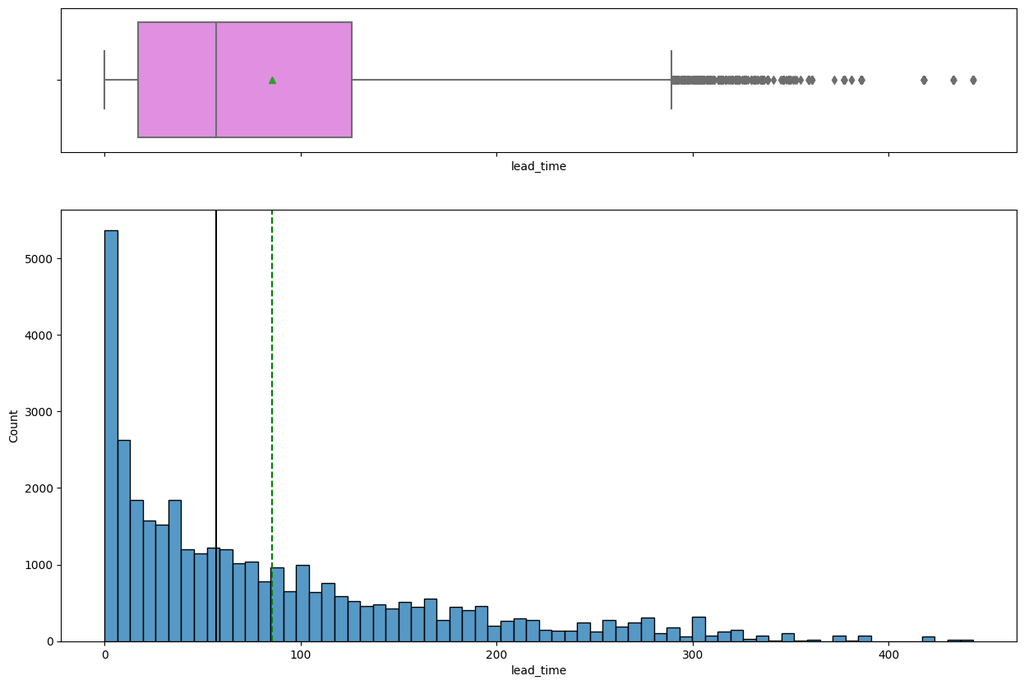

```python
histogram_boxplot(data, 'lead_time')
```

- Distribution is highly right skewed with the presence of outliers.
- It may not make sense for a customer to have made a reservation for over 400 days prior to arriving.

### Distribution od Average price per room

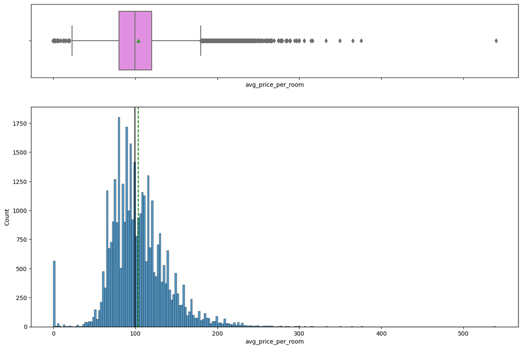

```python
histogram_boxplot(data, 'avg_price_per_room')
```

- Distribution is approximately normal with outliers at both ends.
- There are rooms with no price i.e, 0 euros.
- Rooms with most occuring price counts ranges from like 70 euros to 130 euros.

### Distribution of Number of previous cancellations

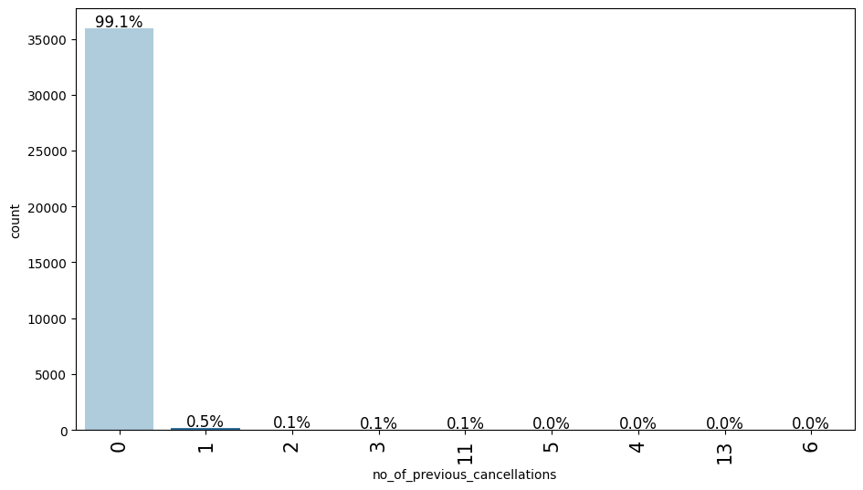

```python
labeled_barplot(data, "no_of_previous_cancellations", perc= True)
```

```python
data.no_of_previous_cancellations.value_counts()
```

```
0     35937
1       198
2        46
3        43
11       25
5        11
4        10
13        4
6         1
Name: no_of_previous_cancellations, dtype: int64
```

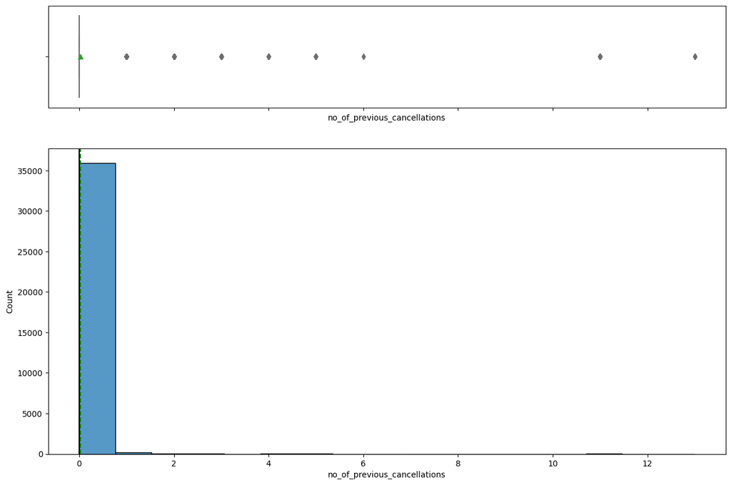

```python
histogram_boxplot(data, 'no_of_previous_cancellations')
```

### Distribution of Number of previous bookings not cancelled

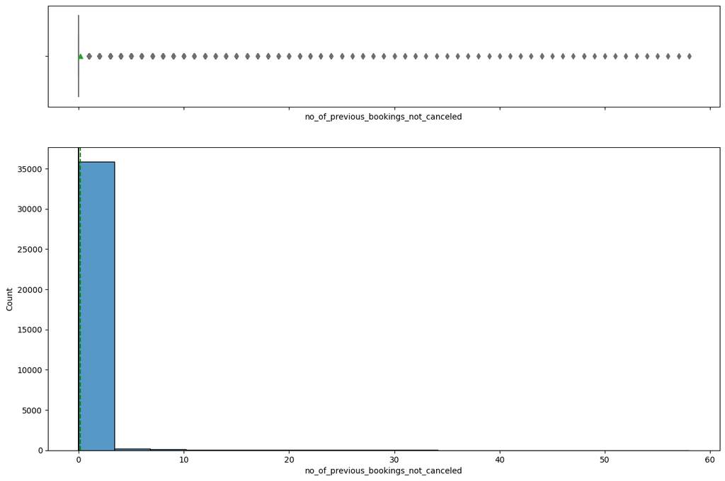

```python
histogram_boxplot(data, 'no_of_previous_bookings_not_canceled')
```

### Distribution of Number of Adults

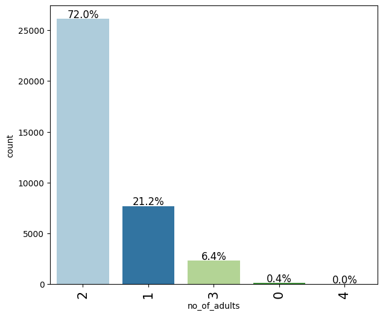

```python
labeled_barplot(data, "no_of_adults", perc = True)
```

- Highest percentage has 2 adults in one booking followed by 1 adult. 0.4% of the bookings did not come from adults.

### Distribution of Number of children

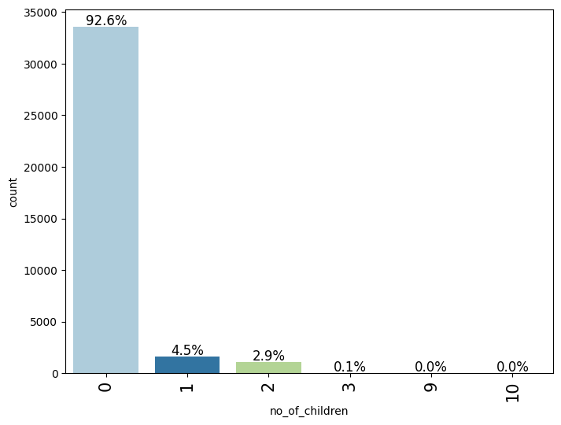

```python
labeled_barplot(data, "no_of_children",perc = True)
```

- Almost 93% of booking did not include children while the maximum number of children booked at a time is 10.

### Distribution of number of weekend nights

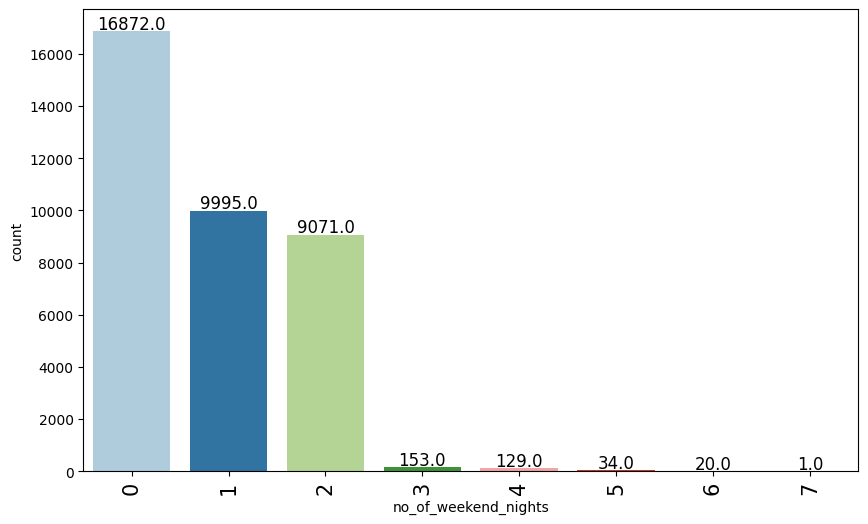

```python
labeled_barplot(data, "no_of_weekend_nights")
```

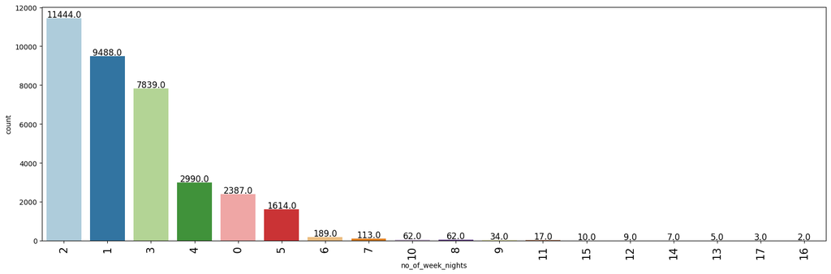

```python
labeled_barplot(data, "no_of_week_nights")
```

- Highest number of the guests stayed or booked for only 2 week nights folowed by booking or staying for only one week night.
- There are two customers that have booked or stayed for 16 week nights each.
- 2387 customers did not book for any week night.

### Distribution of Type of Meal Plan

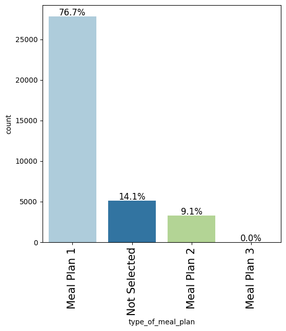

```python
labeled_barplot(data, "type_of_meal_plan",perc = True)
```

- 77 percent of guests booked for only breakfast while 14 percent of customers did not go for any meal plan.

### Distribution of required car parking space

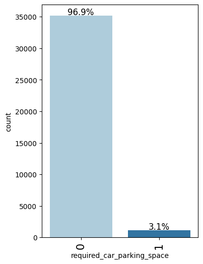

```python
labeled_barplot(data, "required_car_parking_space", perc = True)
```

- 97% of customers did not require car parking space ,only 3% required car parking space.

### Distribution of room type reserved

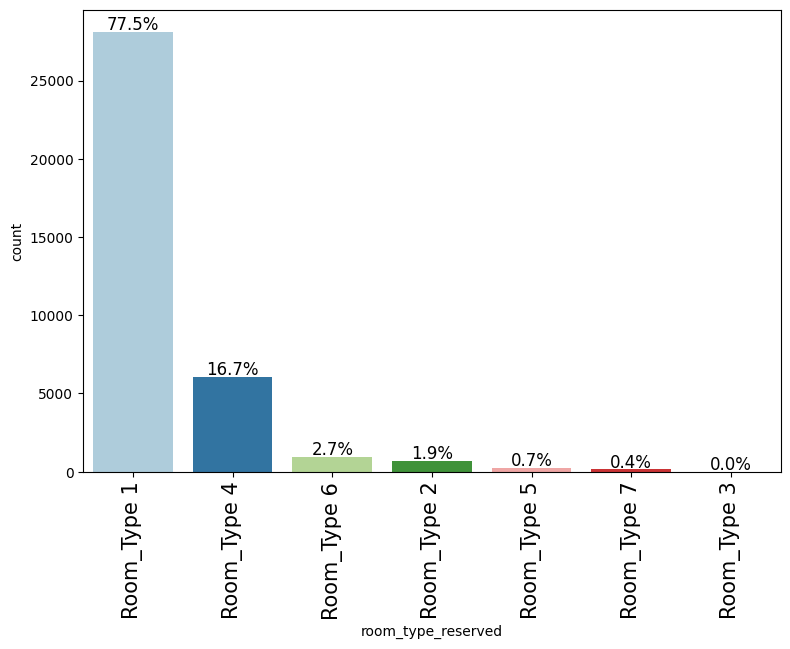

```python
labeled_barplot(data, "room_type_reserved", perc = True)
```

### Distribution of Arrival month

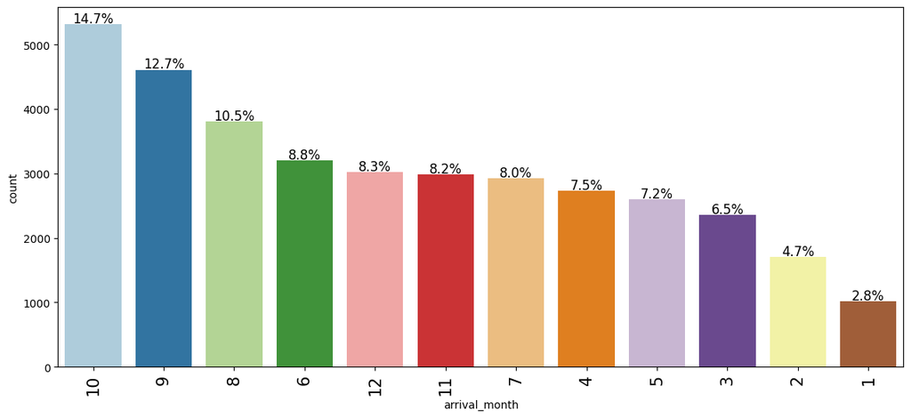

```python
labeled_barplot(data, "arrival_month", perc = True)
```

- 15% of the guests booked for the month of October followed by 13% for September and 10.5% for August. These three months are the top 3 busiest months of the year. This answers the first EDA question.
- June and December completes the top five busiest months of the year for INN Hotel.

### Distribution of Market segment type

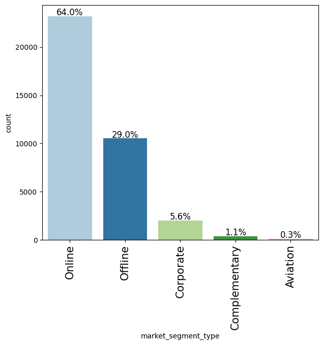

```python
labeled_barplot(data, "market_segment_type", perc = True)
```

- Most of the guests come from Online marketing followed by offline and corporate marketing. This answers the second EDA question.

### Distribution of Repeated guest

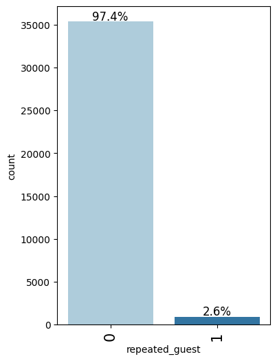

```python
labeled_barplot(data, "repeated_guest", perc = True)
```

- 97% of the customers are not repeated guests

### Distribution of number of previous cancellations

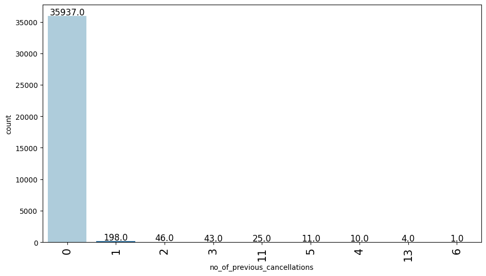

```python
labeled_barplot(data, "no_of_previous_cancellations")
```

### Distribution of number of special requests

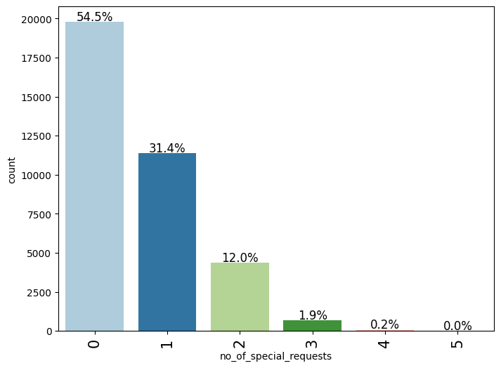

```python
labeled_barplot(data, "no_of_special_requests", perc = True)
```

- 55% of the customers did not make any special requests.

### Distribution of Booking status

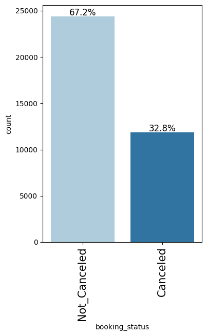

```python
labeled_barplot(data, "booking_status", perc = True)
```

- Almost 33% of the bookings were cancelled and this is a major issue for INN Hotel. This answers the 4th EDA question.

### Bivariate Analysis

Correlation check

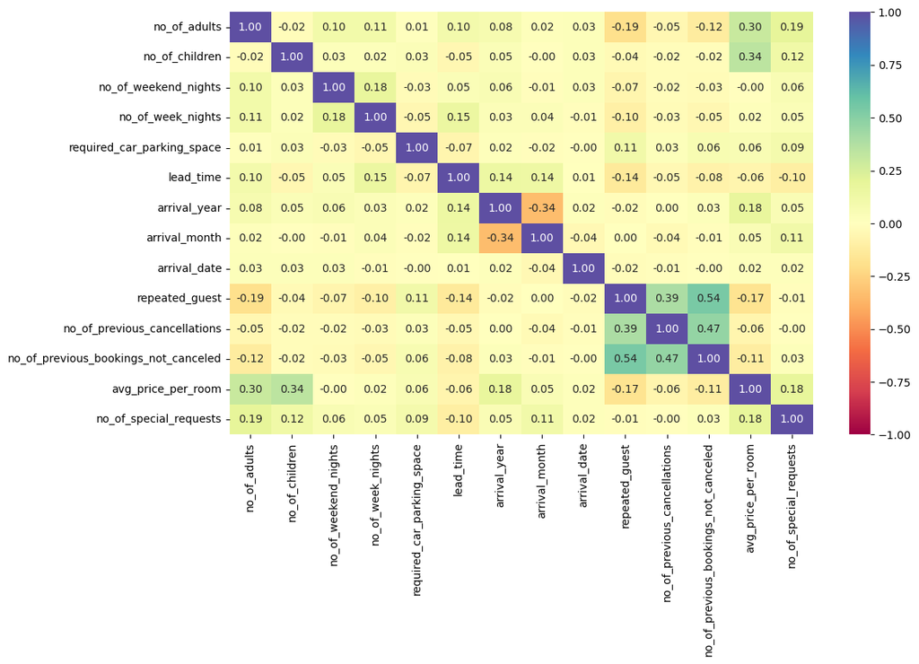

```python
# Creating a list of all numerical variables
cols_list = data.select_dtypes(include=np.number).columns.tolist()


plt.figure(figsize=(12, 7))
sns.heatmap(
    data[cols_list].corr(), annot=True, vmin=-1, vmax=1, fmt=".2f", cmap="Spectral"
)
plt.show()
```

- Repeated guests is positively correlated with the number of previous bookings not canceled and canceled.
- Number of adults and number of children is positively correlated to the average price per room.
- Average price per room is negatively correlated to lead time.

Question 3. Hotel rates are dynamic and change according to demand and customer demographics. What are the differences in room prices in different market segments?

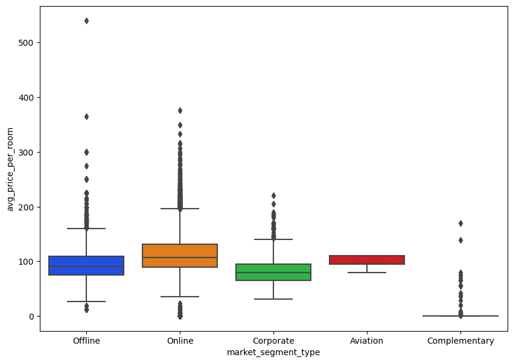

```python
plt.figure(figsize=(10, 7))
sns.boxplot(
  data=data, x="market_segment_type", y="avg_price_per_room", palette="bright"
)
plt.show()
```

```python
data.groupby(['market_segment_type'])['avg_price_per_room'].max()
```

```
market_segment_type
Aviation        110.00000
Complementary   170.00000
Corporate       220.00000
Offline         540.00000
Online          375.50000
Name: avg_price_per_room, dtype: float64
```

```python
### function to plot distributions wrt target


def distribution_plot_wrt_target(data, predictor, target):

    fig, axs = plt.subplots(2, 2, figsize=(12, 10))

    target_uniq = data[target].unique()

    axs[0, 0].set_title("Distribution of target for target=" + str(target_uniq[0]))
    sns.histplot(
        data=data[data[target] == target_uniq[0]],
        x=predictor,
        kde=True,
        ax=axs[0, 0],
        color="teal",
        stat="density",
    )

    axs[0, 1].set_title("Distribution of target for target=" + str(target_uniq[1]))
    sns.histplot(
        data=data[data[target] == target_uniq[1]],
        x=predictor,
        kde=True,
        ax=axs[0, 1],
        color="orange",
        stat="density",
    )

    axs[1, 0].set_title("Boxplot w.r.t target")
    sns.boxplot(data=data, x=target, y=predictor, ax=axs[1, 0], palette="gist_rainbow")

    axs[1, 1].set_title("Boxplot (without outliers) w.r.t target")
    sns.boxplot(
        data=data,
        x=target,
        y=predictor,
        ax=axs[1, 1],
        showfliers=False,
        palette="gist_rainbow",
    )

    plt.tight_layout()
    plt.show()
```

```python
def stacked_barplot(data, predictor, target):
    """
    Print the category counts and plot a stacked bar chart

    data: dataframe
    predictor: independent variable
    target: target variable
    """
    count = data[predictor].nunique()
    sorter = data[target].value_counts().index[-1]
    tab1 = pd.crosstab(data[predictor], data[target], margins=True).sort_values(
        by=sorter, ascending=False
    )
    print(tab1)
    print("-" * 120)
    tab = pd.crosstab(data[predictor], data[target], normalize="index").sort_values(
        by=sorter, ascending=False
    )
    tab.plot(kind="bar", stacked=True, figsize=(count + 5, 5))
    plt.legend(
        loc="lower left", frameon=False,
    )
    plt.legend(loc="upper left", bbox_to_anchor=(1, 1))
    plt.show()
```

Question 5.Repeating guests are the guests who stay in the hotel often and are important to brand equity. What percentage of repeating guests cancel?

```
booking_status  Canceled  Not_Canceled    All
repeated_guest
All                11885         24390  36275
0                  11869         23476  35345
1                     16           914    930
------------------------------------------------------------------------------------------------------------------------
```

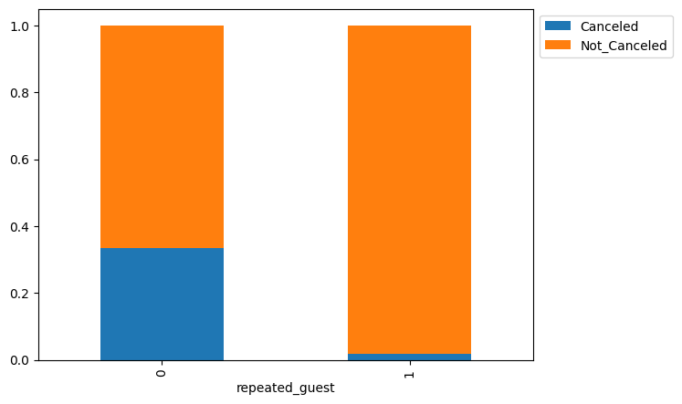

```python
stacked_barplot(data, 'repeated_guest', 'booking_status')
```

- 16 out of 11885 cancelled bookings are from repeating guests. Therefore a very high percentage of the cancelled bookings are not from the repeating guests.

```python
Repeating_guest_perc_cancel = (16/11885)* 100
Repeating_guest_perc_cancel
```

```
0.13462347496844762
```

**checking the percentage of bookings canceled in each month.**

```
arrival_month      1     2     3     4     5     6     7     8     9    10  \
booking_status
All             1014  1704  2358  2736  2598  3203  2920  3813  4611  5317
Not_Canceled     990  1274  1658  1741  1650  1912  1606  2325  3073  3437
Canceled          24   430   700   995   948  1291  1314  1488  1538  1880

arrival_month     11    12    All
booking_status
All             2980  3021  36275
Not_Canceled    2105  2619  24390
Canceled         875   402  11885
------------------------------------------------------------------------------------------------------------------------
```

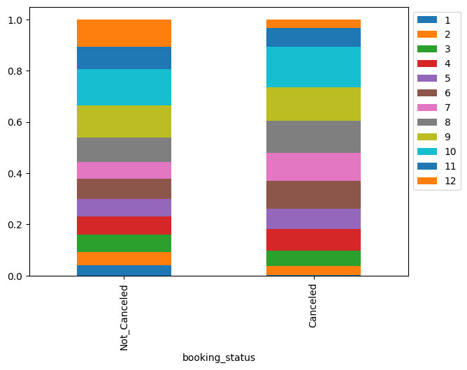

```python
stacked_barplot(data,'booking_status','arrival_month')
```

- Lowest booking and cancellation occured un the month of January while highest booking and cancellation occured in the month of October.

Question 6. Many guests have special requirements when booking a hotel room. Do these requirements affect booking cancellation?

```
no_of_special_requests      0      1     2    3   4  5    All
booking_status
Not_Canceled            11232   8670  3727  675  78  8  24390
All                     19777  11373  4364  675  78  8  36275
Canceled                 8545   2703   637    0   0  0  11885
------------------------------------------------------------------------------------------------------------------------
```

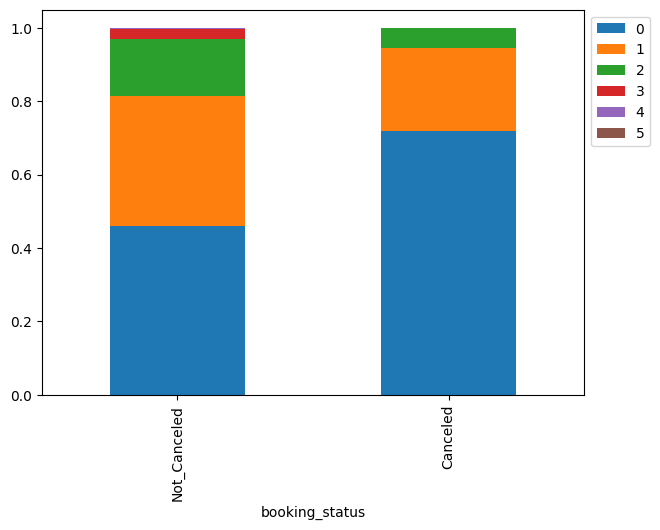

```python
# stacked barplot for no of special requests and booking status.
stacked_barplot(data, 'booking_status','no_of_special_requests')
```

**Correlation between booking status and average price per room**

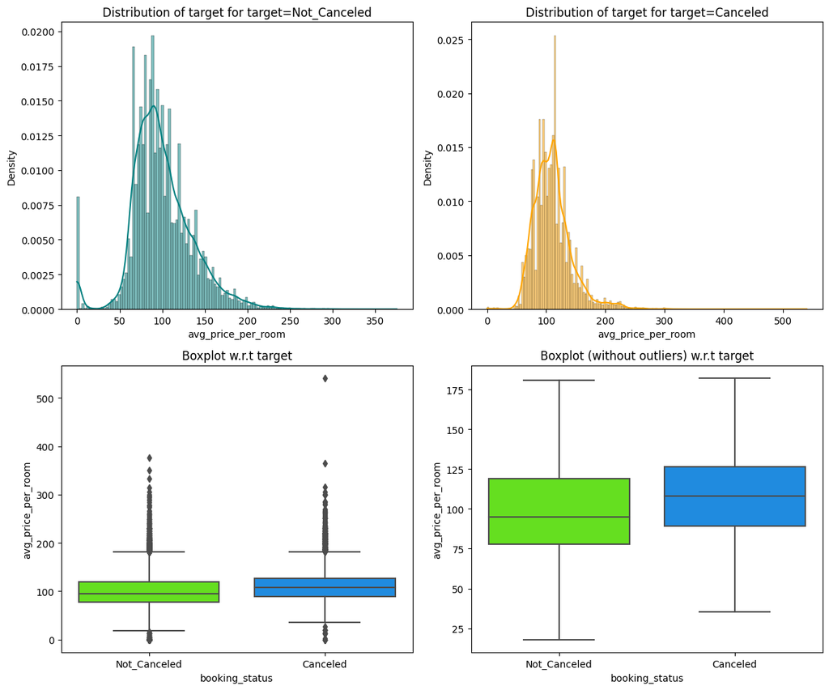

```python
distribution_plot_wrt_target(data, "avg_price_per_room", "booking_status")
```

- Cancellation occurs at high average prices.
- most used rooms ranges from about 70 euros to 130 euros.

**Correlation between booking status and lead time**

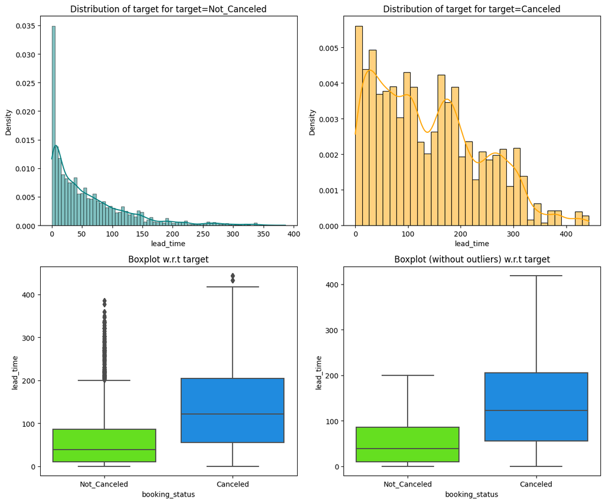

```python
distribution_plot_wrt_target(data, "lead_time", "booking_status")
```

- Cancellation occures at high lead times

## Data Preprocessing

- Missing value treatment (if needed)
- Feature engineering (if needed)
- Outlier detection and treatment (if needed)
- Preparing data for modeling
- Any other preprocessing steps (if needed)

```python
data.drop(["arrival_year", "arrival_date"], axis=1, inplace=True)
```

### Outlier Check

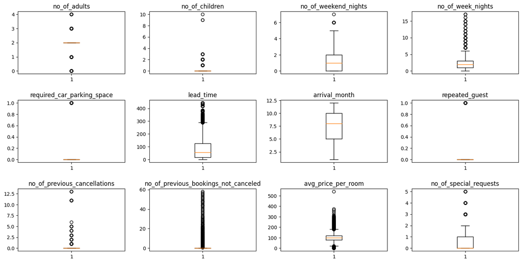

```python
# outlier detection using boxplot
numeric_columns = data.select_dtypes(include=np.number).columns.tolist()


plt.figure(figsize=(15, 10))

for i, variable in enumerate(numeric_columns):
    plt.subplot(4, 4, i + 1)
    plt.boxplot(data[variable], whis=1.5)
    plt.tight_layout(pad=2)
    plt.title(variable)

plt.show()
```

- There are a number of outliers in the data especially the zero average price but no treatment will be done.

### Model Building

#### Model evaluation criterion

### Model can make wrong predictions as:

1. Predicting a customer will not cancel their booking but in reality, the customer will cancel their booking.
2. Predicting a customer will cancel their booking but in reality, the customer will not cancel their booking.

### Which case is more important?

- Both the cases are important as:
- If we predict that a booking will not be canceled and the booking gets canceled then the hotel will lose resources and will have to bear additional costs of distribution channels.
- If we predict that a booking will get canceled and the booking doesn't get canceled the hotel might not be able to provide satisfactory services to the customer by assuming that this booking will be canceled. This might damage the brand equity.

### How to reduce the losses?

- Hotel would want `F1 Score` to be maximized, greater the F1 score higher are the chances of minimizing False Negatives and False Positives.

#### First, creating functions to calculate different metrics and confusion matrix so that we don't have to use the same code repeatedly for each model.

- The model_performance_classification_statsmodels function will be used to check the model performance of models.
- The confusion_matrix_statsmodels function will be used to plot the confusion matrix.

```python
# defining a function to compute different metrics to check performance of a classification model built using statsmodels
def model_performance_classification_statsmodels(
    model, predictors, target, threshold=0.5
):
    """
    Function to compute different metrics to check classification model performance

    model: classifier
    predictors: independent variables
    target: dependent variable
    threshold: threshold for classifying the observation as class 1
    """

    # checking which probabilities are greater than threshold
    pred_temp = model.predict(predictors) > threshold
    # rounding off the above values to get classes
    pred = np.round(pred_temp)

    acc = accuracy_score(target, pred)  # to compute Accuracy
    recall = recall_score(target, pred)  # to compute Recall
    precision = precision_score(target, pred)  # to compute Precision
    f1 = f1_score(target, pred)  # to compute F1-score

    # creating a dataframe of metrics
    df_perf = pd.DataFrame(
        {"Accuracy": acc, "Recall": recall, "Precision": precision, "F1": f1,},
        index=[0],
    )

    return df_perf
```

```python
# defining a function to plot the confusion_matrix of a classification model


def confusion_matrix_statsmodels(model, predictors, target, threshold=0.5):
    """
    To plot the confusion_matrix with percentages

    model: classifier
    predictors: independent variables
    target: dependent variable
    threshold: threshold for classifying the observation as class 1
    """
    y_pred = model.predict(predictors) > threshold
    cm = confusion_matrix(target, y_pred)
    labels = np.asarray(
        [
            ["{0:0.0f}".format(item) + "\n{0:.2%}".format(item / cm.flatten().sum())]
            for item in cm.flatten()
        ]
    ).reshape(2, 2)

    plt.figure(figsize=(6, 4))
    sns.heatmap(cm, annot=labels, fmt="")
    plt.ylabel("True label")
```

**Data Preparation for modeling (Logistic Regression)**

- Aim is to predict which bookings will be canceled.
- Before proceeding to build a model, there is need to encode categorical features.
- Data will be split into train and test to be able to evaluate the model that we build on the train data.

**Encoding cancelled bookings as 1 and non_cancelled bookings as 0 .**

```python
data["booking_status"] = data["booking_status"].apply(lambda x: 1 if x == "Canceled" else 0)
```

```python
X = data.drop(["booking_status"], axis=1)
Y = data["booking_status"]

# adding constant
X = sm.add_constant(X)

X = pd.get_dummies(X, columns = X.select_dtypes(include = ['object','category']).columns.tolist(),drop_first= True)

# Splitting data in train and test sets
X_train, X_test, y_train, y_test = train_test_split(X,Y , test_size= 0.30, random_state=1 )
```

```python
print("Shape of Training set : ", X_train.shape)
print("Shape of test set : ", X_test.shape)
print("Percentage of classes in training set:")
print(y_train.value_counts(normalize=True))
print("Percentage of classes in test set:")
print(y_test.value_counts(normalize=True))
```

```
Shape of Training set :  (25392, 26)
Shape of test set :  (10883, 26)
Percentage of classes in training set:
0   0.67064
1   0.32936
Name: booking_status, dtype: float64
Percentage of classes in test set:
0   0.67638
1   0.32362
Name: booking_status, dtype: float64
```

## EDA

- It is a good idea to explore the data once again after manipulating it.

```python
X_train.head()
```

|  | const | no_of_adults | no_of_children | no_of_weekend_nights | no_of_week_nights | required_car_parking_space | lead_time | arrival_month | repeated_guest | no_of_previous_cancellations | no_of_previous_bookings_not_canceled | avg_price_per_room | no_of_special_requests | type_of_meal_plan_Meal Plan 2 | type_of_meal_plan_Meal Plan 3 | type_of_meal_plan_Not Selected | room_type_reserved_Room_Type 2 | room_type_reserved_Room_Type 3 | room_type_reserved_Room_Type 4 | room_type_reserved_Room_Type 5 | room_type_reserved_Room_Type 6 | room_type_reserved_Room_Type 7 | market_segment_type_Complementary | market_segment_type_Corporate | market_segment_type_Offline | market_segment_type_Online |
| --- | --- | --- | --- | --- | --- | --- | --- | --- | --- | --- | --- | --- | --- | --- | --- | --- | --- | --- | --- | --- | --- | --- | --- | --- | --- | --- |
| 13662 | 1.00000 | 1 | 0 | 0 | 1 | 0 | 163 | 10 | 0 | 0 | 0 | 115.00000 | 0 | 0 | 0 | 0 | 0 | 0 | 0 | 0 | 0 | 0 | 0 | 0 | 1 | 0 |
| 26641 | 1.00000 | 2 | 0 | 0 | 3 | 0 | 113 | 3 | 0 | 0 | 0 | 78.15000 | 1 | 0 | 0 | 0 | 1 | 0 | 0 | 0 | 0 | 0 | 0 | 0 | 0 | 1 |
| 17835 | 1.00000 | 2 | 0 | 2 | 3 | 0 | 359 | 10 | 0 | 0 | 0 | 78.00000 | 1 | 0 | 0 | 0 | 0 | 0 | 0 | 0 | 0 | 0 | 0 | 0 | 1 | 0 |
| 21485 | 1.00000 | 2 | 0 | 0 | 3 | 0 | 136 | 6 | 0 | 0 | 0 | 85.50000 | 0 | 0 | 0 | 1 | 0 | 0 | 0 | 0 | 0 | 0 | 0 | 0 | 0 | 1 |
| 5670 | 1.00000 | 2 | 0 | 1 | 2 | 0 | 21 | 8 | 0 | 0 | 0 | 151.00000 | 0 | 0 | 0 | 0 | 0 | 0 | 0 | 0 | 0 | 0 | 0 | 0 | 0 | 1 |

```python
X_train.shape
```

```
(25392, 26)
```

```python
X_train.describe().T
```

|  | count | mean | std | min | 25% | 50% | 75% | max |
| --- | --- | --- | --- | --- | --- | --- | --- | --- |
| const | 25392.00000 | 1.00000 | 0.00000 | 1.00000 | 1.00000 | 1.00000 | 1.00000 | 1.00000 |
| no_of_adults | 25392.00000 | 1.84546 | 0.51969 | 0.00000 | 2.00000 | 2.00000 | 2.00000 | 4.00000 |
| no_of_children | 25392.00000 | 0.10574 | 0.40783 | 0.00000 | 0.00000 | 0.00000 | 0.00000 | 10.00000 |
| no_of_weekend_nights | 25392.00000 | 0.81734 | 0.87335 | 0.00000 | 0.00000 | 1.00000 | 2.00000 | 6.00000 |
| no_of_week_nights | 25392.00000 | 2.20601 | 1.41033 | 0.00000 | 1.00000 | 2.00000 | 3.00000 | 17.00000 |
| required_car_parking_space | 25392.00000 | 0.03162 | 0.17500 | 0.00000 | 0.00000 | 0.00000 | 0.00000 | 1.00000 |
| lead_time | 25392.00000 | 85.42832 | 86.06759 | 0.00000 | 17.00000 | 57.00000 | 126.00000 | 443.00000 |
| arrival_month | 25392.00000 | 7.42608 | 3.07260 | 1.00000 | 5.00000 | 8.00000 | 10.00000 | 12.00000 |
| repeated_guest | 25392.00000 | 0.02544 | 0.15746 | 0.00000 | 0.00000 | 0.00000 | 0.00000 | 1.00000 |
| no_of_previous_cancellations | 25392.00000 | 0.02426 | 0.37513 | 0.00000 | 0.00000 | 0.00000 | 0.00000 | 13.00000 |
| no_of_previous_bookings_not_canceled | 25392.00000 | 0.15572 | 1.78238 | 0.00000 | 0.00000 | 0.00000 | 0.00000 | 58.00000 |
| avg_price_per_room | 25392.00000 | 103.52847 | 35.29754 | 0.00000 | 80.30000 | 99.71000 | 120.88500 | 540.00000 |
| no_of_special_requests | 25392.00000 | 0.62027 | 0.78801 | 0.00000 | 0.00000 | 0.00000 | 1.00000 | 5.00000 |
| type_of_meal_plan_Meal Plan 2 | 25392.00000 | 0.09212 | 0.28919 | 0.00000 | 0.00000 | 0.00000 | 0.00000 | 1.00000 |
| type_of_meal_plan_Meal Plan 3 | 25392.00000 | 0.00020 | 0.01403 | 0.00000 | 0.00000 | 0.00000 | 0.00000 | 1.00000 |
| type_of_meal_plan_Not Selected | 25392.00000 | 0.13989 | 0.34688 | 0.00000 | 0.00000 | 0.00000 | 0.00000 | 1.00000 |
| room_type_reserved_Room_Type 2 | 25392.00000 | 0.01942 | 0.13798 | 0.00000 | 0.00000 | 0.00000 | 0.00000 | 1.00000 |
| room_type_reserved_Room_Type 3 | 25392.00000 | 0.00024 | 0.01537 | 0.00000 | 0.00000 | 0.00000 | 0.00000 | 1.00000 |
| room_type_reserved_Room_Type 4 | 25392.00000 | 0.16718 | 0.37314 | 0.00000 | 0.00000 | 0.00000 | 0.00000 | 1.00000 |
| room_type_reserved_Room_Type 5 | 25392.00000 | 0.00725 | 0.08482 | 0.00000 | 0.00000 | 0.00000 | 0.00000 | 1.00000 |
| room_type_reserved_Room_Type 6 | 25392.00000 | 0.02674 | 0.16133 | 0.00000 | 0.00000 | 0.00000 | 0.00000 | 1.00000 |
| room_type_reserved_Room_Type 7 | 25392.00000 | 0.00465 | 0.06801 | 0.00000 | 0.00000 | 0.00000 | 0.00000 | 1.00000 |
| market_segment_type_Complementary | 25392.00000 | 0.01079 | 0.10332 | 0.00000 | 0.00000 | 0.00000 | 0.00000 | 1.00000 |
| market_segment_type_Corporate | 25392.00000 | 0.05529 | 0.22856 | 0.00000 | 0.00000 | 0.00000 | 0.00000 | 1.00000 |
| market_segment_type_Offline | 25392.00000 | 0.28891 | 0.45326 | 0.00000 | 0.00000 | 0.00000 | 1.00000 | 1.00000 |
| market_segment_type_Online | 25392.00000 | 0.64166 | 0.47952 | 0.00000 | 0.00000 | 1.00000 | 1.00000 | 1.00000 |

## Checking Multicollinearity

- In order to make statistical inferences from a logistic regression model and avoid errors, it is important to ensure that there is no multicollinearity present in the data.

```python
# Defining a function to check VIF
def checking_vif(predictors):
    vif = pd.DataFrame()
    vif["feature"] = predictors.columns

    # calculating VIF for each feature
    vif["VIF"] = [
        variance_inflation_factor(predictors.values, i)
        for i in range(len(predictors.columns))
    ]
    return vif
```

```python
checking_vif(X_train)
```

|  | feature | VIF |
| --- | --- | --- |
| 0 | const | 326.12615 |
| 1 | no_of_adults | 1.34622 |
| 2 | no_of_children | 1.97732 |
| 3 | no_of_weekend_nights | 1.06731 |
| 4 | no_of_week_nights | 1.09532 |
| 5 | required_car_parking_space | 1.03970 |
| 6 | lead_time | 1.24592 |
| 7 | arrival_month | 1.05153 |
| 8 | repeated_guest | 1.78099 |
| 9 | no_of_previous_cancellations | 1.39449 |
| 10 | no_of_previous_bookings_not_canceled | 1.64727 |
| 11 | avg_price_per_room | 1.93621 |
| 12 | no_of_special_requests | 1.24501 |
| 13 | type_of_meal_plan_Meal Plan 2 | 1.20269 |
| 14 | type_of_meal_plan_Meal Plan 3 | 1.02520 |
| 15 | type_of_meal_plan_Not Selected | 1.23659 |
| 16 | room_type_reserved_Room_Type 2 | 1.10042 |
| 17 | room_type_reserved_Room_Type 3 | 1.00321 |
| 18 | room_type_reserved_Room_Type 4 | 1.35775 |
| 19 | room_type_reserved_Room_Type 5 | 1.02734 |
| 20 | room_type_reserved_Room_Type 6 | 1.96492 |
| 21 | room_type_reserved_Room_Type 7 | 1.11492 |
| 22 | market_segment_type_Complementary | 4.49951 |
| 23 | market_segment_type_Corporate | 16.90190 |
| 24 | market_segment_type_Offline | 63.94951 |
| 25 | market_segment_type_Online | 71.05326 |

- Their is no multicollinearity amongst the variables except for some of the categorical levels of a variable have VIF>5 which can simply be ignored.

## Building a Logistic Regression model

```python
# fitting logistic regression model
logit = sm.Logit(y_train, X_train.astype(float))
lg = logit.fit(disp= False)

print(lg.summary())
```

```
                           Logit Regression Results
==============================================================================
Dep. Variable:         booking_status   No. Observations:                25392
Model:                          Logit   Df Residuals:                    25366
Method:                           MLE   Df Model:                           25
Date:                Fri, 14 Apr 2023   Pseudo R-squ.:                  0.3274
Time:                        18:09:20   Log-Likelihood:                -10822.
converged:                      False   LL-Null:                       -16091.
Covariance Type:            nonrobust   LLR p-value:                     0.000
========================================================================================================
                                           coef    std err          z      P>|z|      [0.025      0.975]
--------------------------------------------------------------------------------------------------------
const                                   -2.4279      0.262     -9.251      0.000      -2.942      -1.913
no_of_adults                             0.1012      0.038      2.695      0.007       0.028       0.175
no_of_children                           0.1631      0.057      2.870      0.004       0.052       0.274
no_of_weekend_nights                     0.1083      0.020      5.487      0.000       0.070       0.147
no_of_week_nights                        0.0405      0.012      3.296      0.001       0.016       0.065
required_car_parking_space              -1.6213      0.138    -11.781      0.000      -1.891      -1.352
lead_time                                0.0163      0.000     63.035      0.000       0.016       0.017
arrival_month                           -0.0615      0.006    -10.280      0.000      -0.073      -0.050
repeated_guest                          -2.3702      0.609     -3.891      0.000      -3.564      -1.176
no_of_previous_cancellations             0.2665      0.086      3.105      0.002       0.098       0.435
no_of_previous_bookings_not_canceled    -0.1624      0.147     -1.108      0.268      -0.450       0.125
avg_price_per_room                       0.0201      0.001     28.015      0.000       0.019       0.022
no_of_special_requests                  -1.4549      0.030    -48.654      0.000      -1.513      -1.396
type_of_meal_plan_Meal Plan 2            0.0471      0.064      0.735      0.462      -0.078       0.173
type_of_meal_plan_Meal Plan 3           18.6582   9200.802      0.002      0.998    -1.8e+04    1.81e+04
type_of_meal_plan_Not Selected           0.3442      0.052      6.572      0.000       0.242       0.447
room_type_reserved_Room_Type 2          -0.3747      0.130     -2.879      0.004      -0.630      -0.120
room_type_reserved_Room_Type 3           0.0494      1.299      0.038      0.970      -2.496       2.594
room_type_reserved_Room_Type 4          -0.2598      0.053     -4.901      0.000      -0.364      -0.156
room_type_reserved_Room_Type 5          -0.6819      0.210     -3.253      0.001      -1.093      -0.271
room_type_reserved_Room_Type 6          -1.0238      0.146     -7.009      0.000      -1.310      -0.737
room_type_reserved_Room_Type 7          -1.4600      0.294     -4.968      0.000      -2.036      -0.884
market_segment_type_Complementary      -25.6305   9202.371     -0.003      0.998   -1.81e+04     1.8e+04
market_segment_type_Corporate           -1.3068      0.266     -4.906      0.000      -1.829      -0.785
market_segment_type_Offline             -2.3268      0.255     -9.127      0.000      -2.826      -1.827
market_segment_type_Online              -0.4955      0.252     -1.968      0.049      -0.989      -0.002
========================================================================================================
```

**Observations**

- Negative values of the coefficient show that the probability of INN Hotel having booking status as canceled decreases with the increase of the corresponding attribute value.
- Positive values of the coefficient show that the probability of INN Hotel having booking status as canceled increases with the increase of the corresponding attribute value.
- p-value of a variable indicates if the variable is significant or not. If we consider the significance level to be 0.05 (5%), then any variable with a p-value less than 0.05 would be considered significant.

## Model performance evaluation

```python
print("Training performance:")
model_performance_classification_statsmodels(lg, X_train, y_train)
```

```
Training performance:
```

|  | Accuracy | Recall | Precision | F1 |
| --- | --- | --- | --- | --- |
| 0 | 0.80356 | 0.62585 | 0.73791 | 0.67728 |

**Observations**

- The f1_score of the model is ~0.68 and we will try to maximize it further
- The variables used to build the model might contain multicollinearity, which will affect the p-values
- We will have to remove multicollinearity from the data to get reliable coefficients and p-values

#### Dropping high p-value variables

- We will drop the predictor variables having a p-value greater than 0.05 as they do not significantly impact the target variable.
- But sometimes p-values change after dropping a variable. So, we'll not drop all variables at once.
- Instead, we will do the following:
  - Build a model, check the p-values of the variables, and drop the column with the highest p-value.
  - Create a new model without the dropped feature, check the p-values of the variables, and drop the column with the highest p-value.
  - Repeat the above two steps till there are no columns with p-value > 0.05.

The above process can also be done manually by picking one variable at a time that has a high p-value, dropping it, and building a model again. But that might be a little tedious and using a loop will be more efficient.

```python
# initial list of columns
cols = X_train.columns.tolist()

# setting an initial max p-value
max_p_value = 1

while len(cols) > 0:
    # defining the train set
    x_train_aux = X_train[cols]

    # fitting the model
    model = sm.Logit(y_train, x_train_aux).fit(disp=False)

    # getting the p-values and the maximum p-value
    p_values = model.pvalues
    max_p_value = max(p_values)

    # name of the variable with maximum p-value
    feature_with_p_max = p_values.idxmax()

    if max_p_value > 0.05:
        cols.remove(feature_with_p_max)
    else:
        break

selected_features = cols
print(selected_features)
```

[output not shown]

```python
X_train1 = X_train[selected_features]
X_test1 = X_test[selected_features]
```

```python
logit1 = sm.Logit(y_train, X_train1.astype(float))
lg1 = logit1.fit(disp = False)

print(lg1.summary())
```

```
                           Logit Regression Results
==============================================================================
Dep. Variable:         booking_status   No. Observations:                25392
Model:                          Logit   Df Residuals:                    25372
Method:                           MLE   Df Model:                           19
Date:                Fri, 14 Apr 2023   Pseudo R-squ.:                  0.3264
Time:                        18:09:43   Log-Likelihood:                -10838.
converged:                       True   LL-Null:                       -16091.
Covariance Type:            nonrobust   LLR p-value:                     0.000
==================================================================================================
                                     coef    std err          z      P>|z|      [0.025      0.975]
--------------------------------------------------------------------------------------------------
const                             -2.9597      0.107    -27.589      0.000      -3.170      -2.749
no_of_adults                       0.0955      0.037      2.565      0.010       0.023       0.168
no_of_children                     0.1581      0.057      2.783      0.005       0.047       0.269
no_of_weekend_nights               0.1103      0.020      5.594      0.000       0.072       0.149
no_of_week_nights                  0.0423      0.012      3.453      0.001       0.018       0.066
required_car_parking_space        -1.6212      0.138    -11.777      0.000      -1.891      -1.351
lead_time                          0.0163      0.000     63.684      0.000       0.016       0.017
arrival_month                     -0.0621      0.006    -10.394      0.000      -0.074      -0.050
repeated_guest                    -2.7033      0.559     -4.833      0.000      -3.800      -1.607
no_of_previous_cancellations       0.2270      0.077      2.958      0.003       0.077       0.377
avg_price_per_room                 0.0206      0.001     29.717      0.000       0.019       0.022
no_of_special_requests            -1.4562      0.030    -48.762      0.000      -1.515      -1.398
type_of_meal_plan_Not Selected     0.3491      0.052      6.681      0.000       0.247       0.451
room_type_reserved_Room_Type 2    -0.3718      0.130     -2.859      0.004      -0.627      -0.117
room_type_reserved_Room_Type 4    -0.2619      0.053     -4.975      0.000      -0.365      -0.159
room_type_reserved_Room_Type 5    -0.7030      0.209     -3.368      0.001      -1.112      -0.294
room_type_reserved_Room_Type 6    -1.0457      0.146     -7.180      0.000      -1.331      -0.760
room_type_reserved_Room_Type 7    -1.5016      0.293     -5.125      0.000      -2.076      -0.927
market_segment_type_Corporate     -0.8119      0.103     -7.904      0.000      -1.013      -0.611
market_segment_type_Offline       -1.8143      0.050    -36.177      0.000      -1.913      -1.716
==================================================================================================
```

**No categorical feature has p-value greater than 0.05, so we'll consider the features in *X_train1* as the final ones and *lg1* as final model for logistic regression.**

```python
print("Training performance:")
model_performance_classification_statsmodels(lg1, X_train1, y_train)
```

```
Training performance:
```

|  | Accuracy | Recall | Precision | F1 |
| --- | --- | --- | --- | --- |
| 0 | 0.80403 | 0.62621 | 0.73896 | 0.67793 |

- Slightly improved f1 score . It will be compared to other models to kmow the best performing model

#### Converting coefficients to odds

- The coefficients of the logistic regression model are in terms of log(odd), to find the odds we have to take the exponential of the coefficients.
- Therefore, **odds = exp(b)**
- The percentage change in odds is given as **odds = (exp(b) - 1) * 100**

```python
# converting coefficients to odds
odds = np.exp(lg1.params)

# finding the percentage change
perc_change_odds = (np.exp(lg1.params) - 1) * 100

# removing limit from number of columns to display
pd.set_option("display.max_columns", None)

# adding the odds to a dataframe
pd.DataFrame({"Odds": odds, "Change_odd%": perc_change_odds}, index=X_train1.columns).T
```

|  | const | no_of_adults | no_of_children | no_of_weekend_nights | no_of_week_nights | required_car_parking_space | lead_time | arrival_month | repeated_guest | no_of_previous_cancellations | avg_price_per_room | no_of_special_requests | type_of_meal_plan_Not Selected | room_type_reserved_Room_Type 2 | room_type_reserved_Room_Type 4 | room_type_reserved_Room_Type 5 | room_type_reserved_Room_Type 6 | room_type_reserved_Room_Type 7 | market_segment_type_Corporate | market_segment_type_Offline |
| --- | --- | --- | --- | --- | --- | --- | --- | --- | --- | --- | --- | --- | --- | --- | --- | --- | --- | --- | --- | --- |
| Odds | 0.05183 | 1.10019 | 1.17129 | 1.11660 | 1.04319 | 0.19765 | 1.01641 | 0.93977 | 0.06698 | 1.25481 | 1.02078 | 0.23313 | 1.41773 | 0.68949 | 0.76958 | 0.49512 | 0.35146 | 0.22276 | 0.44401 | 0.16295 |
| Change_odd% | -94.81671 | 10.01862 | 17.12857 | 11.66033 | 4.31906 | -80.23475 | 1.64116 | -6.02262 | -93.30163 | 25.48065 | 2.07819 | -76.68746 | 41.77350 | -31.05078 | -23.04186 | -50.48848 | -64.85404 | -77.72369 | -55.59920 | -83.70474 |

**Coefficient interpretations**

- `no_of_adults`: Holding all other features constant a 1 unit change in no of adults will increase the odds of INN Hotel having canceled bookings by ~1.1 times or a ~10% increase in odds of having canceled bookings.
- `required_car_parking_space`: Holding all other features constant a 1 unit change in the required_car_parking_space will decrease the odds of INN Hotel having canceled bookings by ~0.19 times or a decrease of ~80.2% odds of having canceled bookings.

#### Checking model performance on the training set

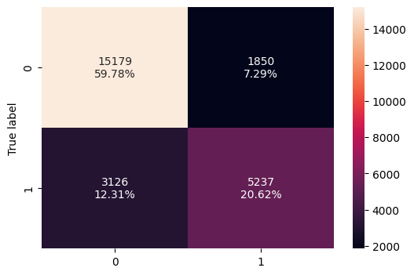

```python
# creating confusion matrix
confusion_matrix_statsmodels(lg1, X_train1, y_train)
```

```python
log_reg_model_train_perf = model_performance_classification_statsmodels(
    lg1, X_train1, y_train
)

print("Training performance:")
log_reg_model_train_perf
```

```
Training performance:
```

|  | Accuracy | Recall | Precision | F1 |
| --- | --- | --- | --- | --- |
| 0 | 0.80403 | 0.62621 | 0.73896 | 0.67793 |

**Test set performance**

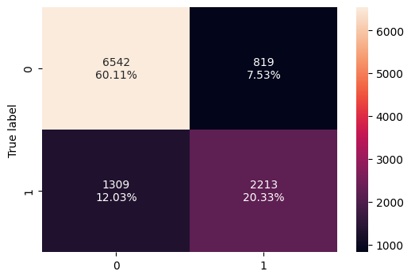

```python
# creating confusion matrix
confusion_matrix_statsmodels(lg1, X_test1, y_test)
```

```python
log_reg_model_test_perf = model_performance_classification_statsmodels(
    lg1, X_test1, y_test
)

print("Test performance:")
log_reg_model_test_perf
```

```
Test performance:
```

|  | Accuracy | Recall | Precision | F1 |
| --- | --- | --- | --- | --- |
| 0 | 0.80447 | 0.62834 | 0.72988 | 0.67531 |

- The model is giving a f1_score of ~0.677 and ~0.675 on the train and test sets respectively
- As the train and test performances are comparable, the model is not overfitting
- Moving forward we will try to improve the performance of the model

## Model Performance Improvement

- Let's see if the f1 score can be improved further, by changing the model threshold using AUC-ROC Curve.

#### ROC-AUC

- ROC-AUC on training set

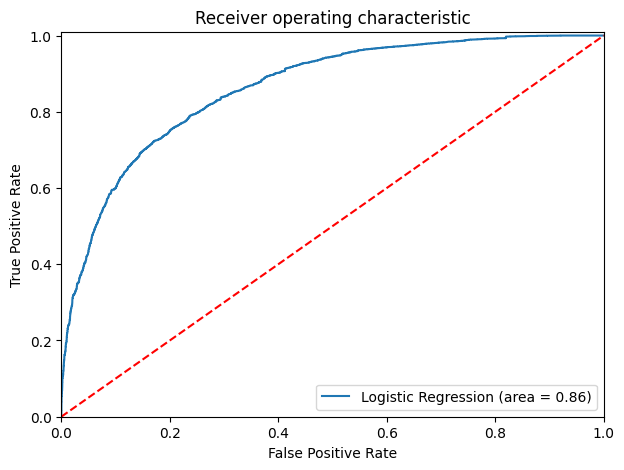

```python
logit_roc_auc_train = roc_auc_score(y_train, lg1.predict(X_train1))
fpr, tpr, thresholds = roc_curve(y_train, lg1.predict(X_train1))
plt.figure(figsize=(7, 5))
plt.plot(fpr, tpr, label="Logistic Regression (area = %0.2f)" % logit_roc_auc_train)
plt.plot([0, 1], [0, 1], "r--")
plt.xlim([0.0, 1.0])
plt.ylim([0.0, 1.01])
plt.xlabel("False Positive Rate")
plt.ylabel("True Positive Rate")
plt.title("Receiver operating characteristic")
plt.legend(loc="lower right")
plt.show()
```

#### Optimal threshold using AUC-ROC curve

```python
# Optimal threshold as per AUC-ROC curve
# The optimal cut off would be where tpr is high and fpr is low
fpr, tpr, thresholds = roc_curve(y_train, lg1.predict(X_train1))

optimal_idx = np.argmax(tpr - fpr)
optimal_threshold_auc_roc = thresholds[optimal_idx]
print(optimal_threshold_auc_roc)
```

```
0.30893774503410903
```

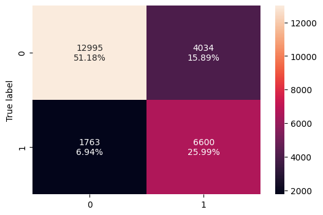

```python
# creating confusion matrix
confusion_matrix_statsmodels(
    lg1, X_train1,y_train ,threshold=optimal_threshold_auc_roc
)
```

```python
# checking model performance for this model
log_reg_model_train_perf_threshold_auc_roc = model_performance_classification_statsmodels(
    lg1, X_train1, y_train, threshold=optimal_threshold_auc_roc
)
print("Training performance:")
log_reg_model_train_perf_threshold_auc_roc
```

```
Training performance:
```

|  | Accuracy | Recall | Precision | F1 |
| --- | --- | --- | --- | --- |
| 0 | 0.77170 | 0.78919 | 0.62065 | 0.69485 |

- There is an increase in f1 score and recall

**Checking model performance on test set**

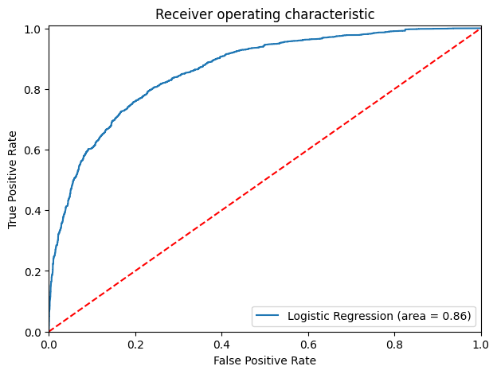

```python
logit_roc_auc_train = roc_auc_score(y_test, lg1.predict(X_test1))
fpr, tpr, thresholds = roc_curve(y_test, lg1.predict(X_test1))
plt.figure(figsize=(7, 5))
plt.plot(fpr, tpr, label="Logistic Regression (area = %0.2f)" % logit_roc_auc_train)
plt.plot([0, 1], [0, 1], "r--")
plt.xlim([0.0, 1.0])
plt.ylim([0.0, 1.01])
plt.xlabel("False Positive Rate")
plt.ylabel("True Positive Rate")
plt.title("Receiver operating characteristic")
plt.legend(loc="lower right")
plt.show()
```

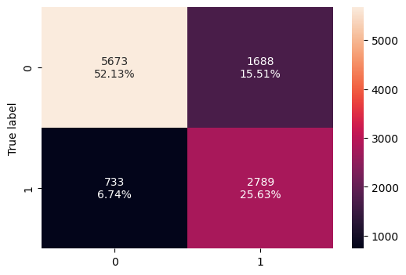

```python
# creating confusion matrix
confusion_matrix_statsmodels(lg1, X_test1, y_test, threshold=optimal_threshold_auc_roc)
```

```python
# checking model performance for this model
log_reg_model_test_perf_threshold_auc_roc = model_performance_classification_statsmodels(
    lg1, X_test1, y_test, threshold=optimal_threshold_auc_roc
)
print("Test performance:")
log_reg_model_test_perf_threshold_auc_roc
```

```
Test performance:
```

|  | Accuracy | Recall | Precision | F1 |
| --- | --- | --- | --- | --- |
| 0 | 0.77754 | 0.79188 | 0.62296 | 0.69734 |